# Untitled

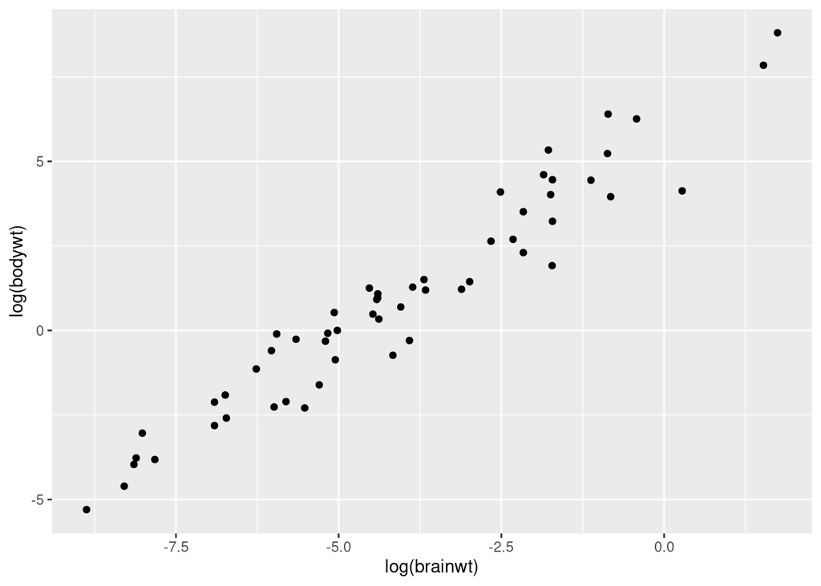

```r
ggplot(aes(log(brainwt), log(bodywt)), data = msleep) + geom_point()
```

19. מה עושה הקוד הבא. האם הוא עובד? האם הוא הגיוני? למה/למה לא? ggplot(mpg) +geom_point(aes(class, cty)) +geom_boxplot(aes(trans, hwy))

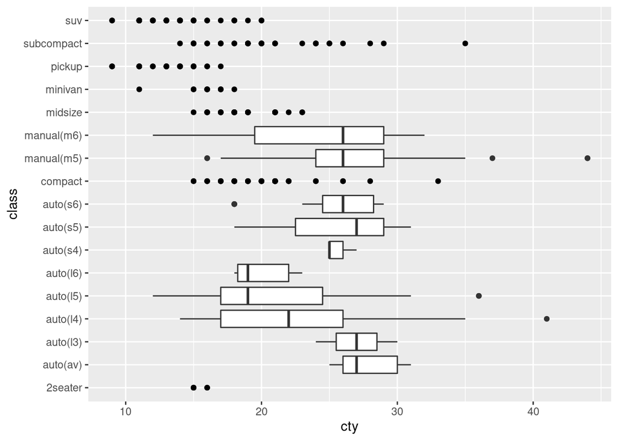

```r
ggplot(mpg) + geom_point(aes(class, cty)) + geom_boxplot(aes(trans, hwy)) + coord_flip()
```

This plot is using mpg dataset as a blank background without setting aesthetics. Then it adds the first layer using scatterplot with class as x-axis and cty on y axis. After that, it adds another layer using boxplot with trans on x-axis and hwy on y-axis.

It doesn’t work because the x-axis: 1. too crowded, need to add coord_flip() to read all the class and trans labels. 2. Trans and class are mixed together, it doesn’t make sense. Also, boxplot is mixed with scatterplot. Y-axis has two different value groups, the hwy and the cty. These two contain both continuous values but are different in nature because one is city miles per gallon, the other is highway miles per gallon. In the end, the x-axis and y-axis labels only have class and cty, it doesn’t label trans and hwy.

20. מה קורה כאשר מנסים בשכבה אחת להשתמש במשתנה רציף ולאחר מכן בשכבה אחרת במשתנה קטגוריאלי? מה קורה עם עושים זאת בסדר הפוך

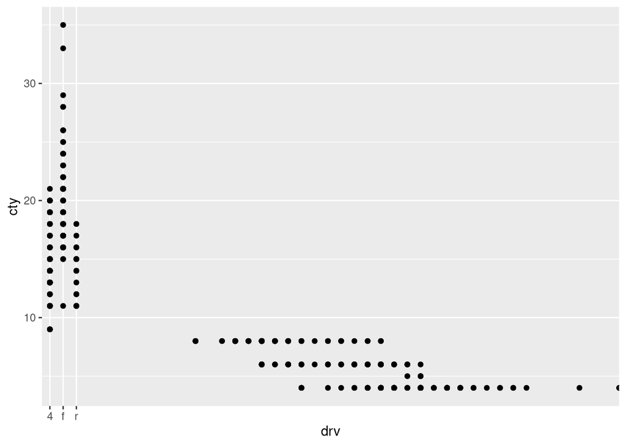

```r
ggplot(mpg) +
  geom_point(aes(drv, cty)) +
  geom_point(aes(hwy, cyl))
```

If you set first x-axis with categorical values, and then with continuous values, the plot will run but the result doesn’t make sense at all. However, if you do it the opposite way, R will report errors.

21. באיזה geom תשתמש בכל אחד מהמצבים הבאים: א. לתאר השתנות משתנה לאורך הזמן ב. לתאור התפלגות משתנה יחיד ג. למקד את תשומת הלב במגמה הכללית בסט נתונים גדול ג. לצייר מפה ד. לשיים (לשים תוויות) על נקודות חריגות

-Display how a variable has changed over time. geom_line() -Show the detailed distribution of a single variable. geom_histogram() -Focus attention on the overall trend in a large dataset. geom_line(), geom_area() -Draw a map. geom_sf(), geom_polygon(), coord_quickmap()  
-Label outlying points. geom_point(), geom_text()